# HW3 - Wenjie Sun (ws854)

## 1

### 1(a)

```r
data("data_corpus_immigrationnews", package = "quantedaData")

#freq of newspapers
paper <- data_corpus_immigrationnews[["paperName"]]$paperName
paper_freq <- as.data.frame(table(paper))
colnames(paper_freq) <- c("paper", "Freq")

print(paper_freq[with(paper_freq,order(-Freq)),])
```

```
##                  paper Freq
## 7            telegraph  511
## 5                 mail  412
## 3             guardian  392
## 9                times  352
## 1              express  325
## 4          independent  324
## 6                  sun  277
## 2                   ft  207
## 8 the-sunday-telegraph   33
```

### 1(b)

```r
top4_list<-paper_freq[with(paper_freq,order(-Freq)),][1:4,]$paper # top 4 papers
print(top4_list)
```

```
## [1] telegraph mail      guardian  times
## 9 Levels: express ft guardian independent mail sun ... times
```

```r
Q1CorpSub <- corpus_subset(data_corpus_immigrationnews,paperName %in% top4_list) #Create the subset

load("custom_stopwords.RData") #load custom_stopwords

Q1dfm <- dfm(Q1CorpSub,stem = F, remove_punct = TRUE , tolower = T, remove = custom_stopwords) #dfm
Q1dfm_trim <-dfm_trim(Q1dfm,min_count = 30,min_docfreq =20)

print(Q1dfm)
```

```
## Document-feature matrix of: 1,667 documents, 46,942 features (99.4% sparse).
```

```r
print(Q1dfm_trim)
```

```
## Document-feature matrix of: 1,667 documents, 3,646 features (94.9% sparse).
```

### 1(c)

##### I think it is important to remove rare words becasue these rare words would not contribute much information for discovering commonly used words to form topics. Also, by removing rare words, this can greatly reduce the size of data and speed up the analysis.

### 1(d)

```r
TM<-LDA(Q1dfm_trim, k = 30, method = "Gibbs",  control = list(seed = 10012,iter = 3000))
print(TM)
```

```
## A LDA_Gibbs topic model with 30 topics.
```

### 1(e)

```r
#The top 10 word for all 30 topics
top30_terms<-get_terms(TM,10)

print(top30_terms)
```

```
##       Topic 1    Topic 2    Topic 3     Topic 4      Topic 5  Topic 6
##  [1,] "tax"      "women"    "farage"    "eu"         "war"    "mail"
##  [2,] "housing"  "family"   "english"   "european"   "food"   "newspapers"
##  [3,] "pay"      "life"     "ukip"      "europe"     "day"    "damonl"
##  [4,] "year"     "children" "interview" "britain"    "world"  "claims"
##  [5,] "market"   "mother"   "racist"    "referendum" "man"    "2014"
##  [6,] "business" "father"   "leader"    "union"      "back"   "newspaper"
##  [7,] "income"   "years"    "asked"     "cameron"    "french" "added"
##  [8,] "prices"   "men"      "made"      "countries"  "car"    "miss"
##  [9,] "growth"   "parents"  "nigel"     "merkel"     "tour"   "yesterday"
## [10,] "money"    "marriage" "romanians" "brussels"   "made"   "made"
##       Topic 7       Topic 8     Topic 9     Topic 10    Topic 11
##  [1,] "british"     "ukip"      "mp"        "school"    "british"
##  [2,] "britain"     "party"     "thatcher"  "children"  "workers"
##  [3,] "white"       "farage"    "tory"      "schools"   "foreign"
```

[output cut: 51 more lines]

```r
# generate doc_topics and words_topics
doc_topics<-TM@gamma
words_topics<-TM@beta
doc_topics <- t(doc_topics)

#calculate the top 5 topics has the highest sum of total contritubion
topic_contribution <- data.frame(total_contribution = rowSums(doc_topics),topic_number = c(1:30),stringsAsFactors = FALSE)
top5_topic <- topic_contribution[with(topic_contribution,order(-total_contribution)),][1:5,]

print(top5_topic)
```

```
##    total_contribution topic_number
## 20           71.92322           20
## 14           70.17120           14
## 15           65.86359           15
## 8            65.64361            8
## 26           63.40987           26
```

```r
# narrow down to top 5 topics
print(get_terms(TM,20)[,top5_topic$topic_number])
```

```
##       Topic 20     Topic 14        Topic 15   Topic 8      Topic 26
##  [1,] "migration"  "ukip"          "book"     "ukip"       "cameron"
##  [2,] "year"       "voters"        "film"     "party"      "election"
##  [3,] "migrants"   "party"         "story"    "farage"     "minister"
##  [4,] "net"        "vote"          "books"    "campaign"   "party"
##  [5,] "britain"    "labour"        "music"    "nigel"      "david"
##  [6,] "figures"    "parties"       "play"     "racist"     "tory"
##  [7,] "uk"         "tories"        "life"     "british"    "conservative"
##  [8,] "number"     "cent"          "show"     "candidate"  "prime"
##  [9,] "eu"         "elections"     "2014"     "european"   "conservatives"
## [10,] "thousands"  "support"       "world"    "leader"     "tories"
## [11,] "countries"  "election"      "theatre"  "election"   "government"
## [12,] "numbers"    "lib"           "american" "ukips"      "coalition"
## [13,] "target"     "conservatives" "called"   "elections"  "campaign"
## [14,] "government" "seats"         "made"     "candidates" "general"
## [15,] "work"       "european"      "america"  "partys"     "leader"
## [16,] "coming"     "political"     "love"     "mep"        "mps"
## [17,] "show"       "poll"          "young"    "poster"     "johnson"
## [18,] "european"   "polls"         "john"     "views"      "boris"
## [19,] "tens"       "dems"          "art"      "country"    "leadership"
## [20,] "statistics" "politics"      "star"     "comments"   "senior"
```

##### Topic 1 - “Migrations”: My guess this topic is about discussing the impact of migrants from EU to UK and some statistics

##### Topic 2 - “Elections” : It is probably discussing how many seats and votes will each party win in the election and (current) poll results.

##### Topic 3 - “Entertainment” : Not too sure if this topic is so relvant to the corpus. But it is all about entertainment.

##### Topic 4 - “UKIP” : I think these news are mainly talking about the Nigel Farage and his party in the right-wing view of immgration and racists views(supporters)

##### Topic 5 - “Conservative Party” : This topic mainly discuss David Cameron and his convservative party.

### 1(f)

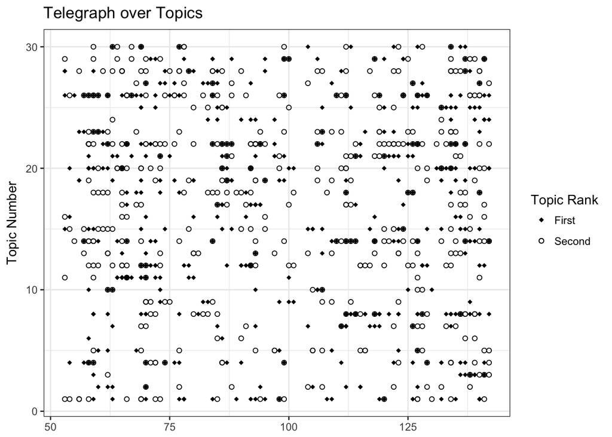

```r
max<-apply(doc_topics, 2, which.max)

which.max2<-function(x){
  which(x == sort(x,partial=(k-1))[k-1])
}
k<-30
max2<- apply(doc_topics, 2, which.max2)
max2<-sapply(max2, max)

index<-seq(1:length(max2))
top2<-data.frame(max = max, max2 = max2,
                 index = index, day = as.integer(Q1CorpSub[["day"]]$day), paperName = Q1CorpSub[["paperName"]]$paperName)

telegraph <- subset(top2,paperName== "telegraph")
telegraph <- telegraph[with(telegraph,order(day)),]

z<-ggplot(telegraph, aes(x=day, y=max, pch="First"))
z + geom_point(aes(x=day, y=max2, pch="Second")) +theme_bw() +
  ylab("Topic Number") + ggtitle("Telegraph over Topics") + geom_point() + xlab(NULL) +
  scale_shape_manual(values=c(18, 1), name = "Topic Rank")
```

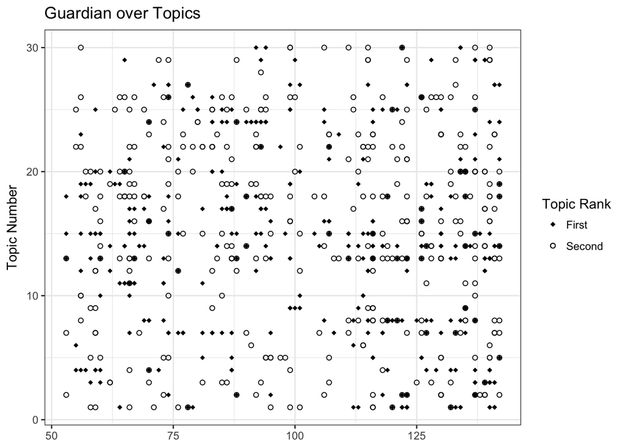

```r
guardian <- subset(top2,paperName== "guardian")
guardian <- guardian[with(guardian,order(day)),]

z<-ggplot(guardian, aes(x=day, y=max, pch="First"))
z + geom_point(aes(x=day, y=max2, pch="Second")) +theme_bw() +
  ylab("Topic Number") + ggtitle("Guardian over Topics") + geom_point() + xlab(NULL) +
  scale_shape_manual(values=c(18, 1), name = "Topic Rank")
```

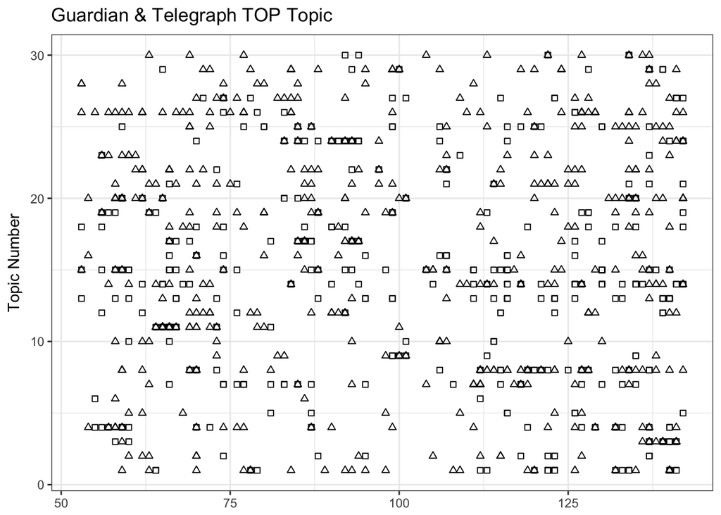

```r
#plot top 1 topic from both papers
both_first <- ggplot() +
      # blue plot
      geom_point(data = guardian, aes(x=day, y=max),pch = 0) +
      # red plot
      geom_point(data=telegraph, aes(x=day, y=max),pch = 2) + theme_bw() +
  ylab("Topic Number") + ggtitle("Guardian & Telegraph TOP Topic") + geom_point() + xlab(NULL)
both_first
```

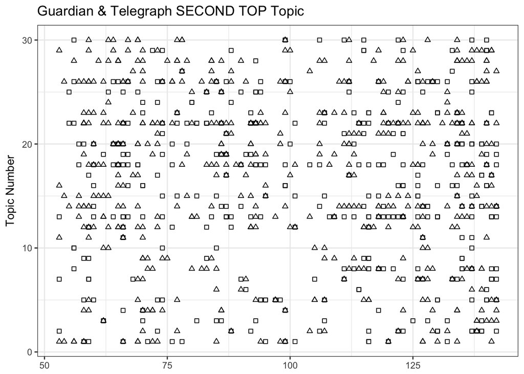

```r
#plot second top topic from both papers
both_second <- ggplot() +
      # blue plot
      geom_point(data = guardian, aes(x=day, y=max2),pch = 0) +
      # red plot
      geom_point(data=telegraph, aes(x=day, y=max2),pch = 2) + theme_bw() +
  ylab("Topic Number") + ggtitle("Guardian & Telegraph SECOND TOP Topic") + geom_point() + xlab(NULL)
both_second
```

##### It seems that Telegraph has more articles about topic 22, 26, and 20; while, Guardian has more articles about topic 13, 14, 15. I also plotted the first and second top topic from each paper in the same chart. Clearly, these two newspaper rarely share same topic on the same day. Also, I think telegraph tends to focus on the same topic a few days in a row.

### 1(g)

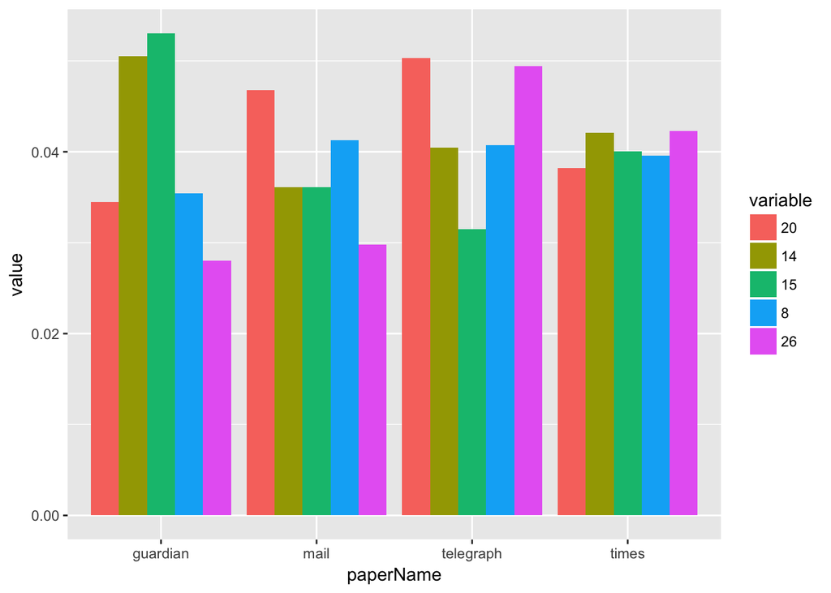

```r
avg_topic<-as.data.frame(TM@gamma[,top5_topic$topic_number])
avg_topic["paperName"] <- Q1CorpSub[["paperName"]]$paperName
avg_topic["day"] <- as.integer(Q1CorpSub[["day"]]$day)
avg_df <- data.frame(matrix(NA,ncol=6,nrow = 1))

for (i in top4_list) {
  s <- colSums(avg_topic[with(avg_topic,avg_topic["paperName"]==i),][,1:5])
  count <- nrow(avg_topic[with(avg_topic,avg_topic["paperName"]==i),])
  avg_df[i,2:6]<- s / count
  avg_df[i,1] <- i
}

#drop out the first row...
avg_df <- avg_df[2:5,]
colnames(avg_df) <- c("paperName",top5_topic$topic_number)

melt_d <- melt(avg_df,id.vars = "paperName")

ggplot(melt_d,aes(x=paperName,y=value,fill=variable))+geom_bar(stat="identity",position="dodge")
```

```r
print(avg_df)
```

```
##           paperName         20         14         15          8         26
## telegraph telegraph 0.05028339 0.04044664 0.03148127 0.04075193 0.04944486
## mail           mail 0.04674524 0.03612247 0.03611887 0.04125273 0.02979785
## guardian   guardian 0.03450908 0.05054091 0.05305002 0.03543029 0.02800189
## times         times 0.03818696 0.04206951 0.04005705 0.03958687 0.04230139
```

##### 2) Times is regarded as a center-right political paper, which seems to be proven here as it covers all top topics evenly.

## 2

### 2(a)

```r
TM1<-LDA(Q1dfm_trim, k = 30, method = "Gibbs",  control = list(seed = 1,iter = 3000))
#TM@iter
```

### 2(b)

```r
#original run
betas <- TM@beta

betas1 <- TM1@beta

#create a dataframe and calculate cosine similarity
cosine_sim <- data.frame(matrix(NA,ncol=3,nrow = 900))
for (i in 1:30) {
  for (j in 1:30){
    old <- betas[i,]
    new <- betas1[j,]
    cosine_sim[(i-1)*30+j,3] <- cosine(old,new)
    cosine_sim[(i-1)*30+j,1] <- i
    cosine_sim[(i-1)*30+j,2] <- j
  }
}

colnames(cosine_sim)<- c("old_topic","new_topic","cosine_similarity")

similar_topics <- data.frame(matrix(NA,ncol=2,nrow = 30))
for (i in 1:30) {
  h<-cosine_sim[with(cosine_sim,new_topic==i),]
  similar_topics[i,2]<- h[with(h,which.max(cosine_similarity)),]$old_topic
  similar_topics[i,1] <- i
}

colnames(similar_topics) <- c("new_topic","old_topic")
print(similar_topics)
```

```
##    new_topic old_topic
## 1          1        27
## 2          2         1
## 3          3         8
## 4          4         6
## 5          5        17
## 6          6        19
## 7          7        15
## 8          8         1
## 9          9        22
## 10        10        12
## 11        11        30
## 12        12        14
## 13        13        26
## 14        14        28
```

[output cut: 16 more lines]

### 2(c)

```r
top30_terms1<-get_terms(TM1,10)

count_of_share_word = 0

for (i in 1:30) {
  new_word = top30_terms1[,i]
  old_word = top30_terms[,similar_topics[i,2]]
  common = length(Reduce(intersect, list(new_word,old_word)))
  count_of_share_word = count_of_share_word + common
}

print(count_of_share_word/30)
```

```
## [1] 5.8
```

### 2(d)

```r
TMA<-LDA(Q1dfm_trim, k = 5, method = "Gibbs",  control = list(seed = 10012,iter = 3000))
TMA1<-LDA(Q1dfm_trim, k = 5, method = "Gibbs",  control = list(seed = 1,iter = 3000))
```

```r
betasa <- TMA@beta

betasa1 <- TMA1@beta

#create a dataframe
cosine_sim_a <- data.frame(matrix(NA,ncol=3,nrow = 25))
for (i in 1:5) {
  for (j in 1:5){
    old <- betasa[i,]
    new <- betasa1[j,]
    cosine_sim_a[(i-1)*5+j,3] <- cosine(old,new)
    cosine_sim_a[(i-1)*5+j,1] <- i
    cosine_sim_a[(i-1)*5+j,2] <- j
  }
}

colnames(cosine_sim_a)<- c("old_topic","new_topic","cosine_similarity")

similar_topics_a <- data.frame(matrix(NA,ncol=2,nrow = 5))
for (i in 1:5) {
  h<-cosine_sim_a[with(cosine_sim_a,new_topic==i),]
  similar_topics_a[i,2]<- h[with(h,which.max(cosine_similarity)),]$old_topic
  similar_topics_a[i,1] <- i
}

colnames(similar_topics_a) <- c("new_topic","old_topic")
print(similar_topics_a)
```

```
##   new_topic old_topic
## 1         1         2
## 2         2         3
## 3         3         5
## 4         4         4
## 5         5         1
```

```r
top30_termsa<-get_terms(TMA,10)
top30_termsa1 <- get_terms(TMA1,10)

count_of_share_word_a = 0

for (i in 1:5) {
  new_word = top30_termsa1[,i]
  old_word = top30_termsa[,similar_topics_a[i,2]]
  common = length(Reduce(intersect, list(new_word,old_word)))
  count_of_share_word_a = count_of_share_word_a + common
}

print(count_of_share_word_a/5)
```

```
## [1] 8
```

##### It is more stable when the topic number is reduced. It makes sense, for example, when there is only one topic, this topic for sure share 100% of the word.